# R course day 3: Plotting

Niek de Klein, Annique Claringbould

# 1 Introduction

You have already explored the **Iris** dataset by determining differences in petal and sepal size of different types of these plants. In this tutorial you will learn how to visualize these difference using different kinds of plots with an external package called **ggplot2**.

**ggplot2** is an R package created by Hadley Wickham in 2005. It can highly improve the quality and aesthetic of your graphs. As you’ve seen in the last days, R also has some built-in plotting functions, but today we will be focusing on **ggplot2**.

Scroll through http://www.r-graph-gallery.com/portfolio/ggplot2-package/ to see some examples of the plots you can make. Clicking on a plot shows the code that was used to make it.

```r
# if you haven't installed it yet, install ggplot2
install.packages('ggplot2')
```

First, we have to load the **ggplot2** package using the `library()` function.

```r
library(ggplot2)
```

# 2 Plotting

## 2.1 Easy example

Now we have loaded the **ggplot2** library lots of new methods are available. The first function you always need when making a ggplot is `ggplot()`. Let’s try the basic function `ggplot()` and `geom_point()` to generate a scatter plot.

The first argument in `ggplot()` is the dataset you want to use to generate the plot, in this case we’re using the **iris** dataset again. The second argument is the `aes()` or aesthetic function, where you can set which variables of the dataset are used for the available visual properties. In the case of this scatterplot we’re only interested in the x and y position of each data point.

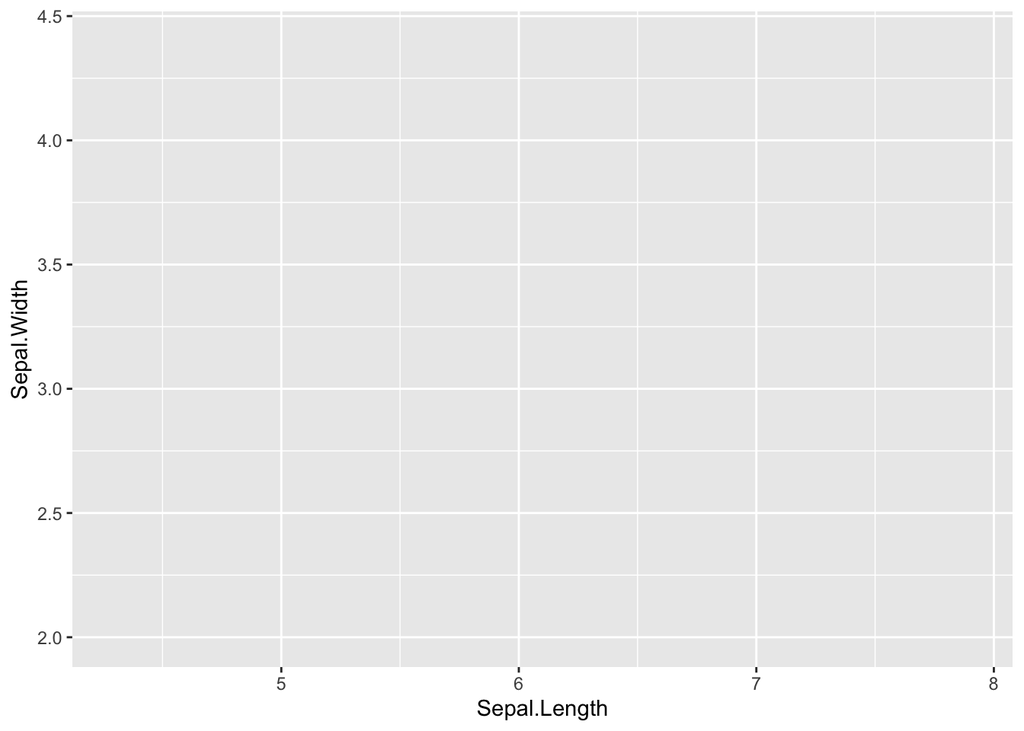

```r
ggplot(iris, aes(x=Sepal.Length, y=Sepal.Width))
```

Just running the command above will generate an empty plot. This is because **ggplot2** doesn’t know what kind of plot you wish to make. The function `geom_point()` will tell **ggplot2** to make a scatterplot. Combining the two functions `ggplot(...) + geom_point()` will result in a scatterplot:

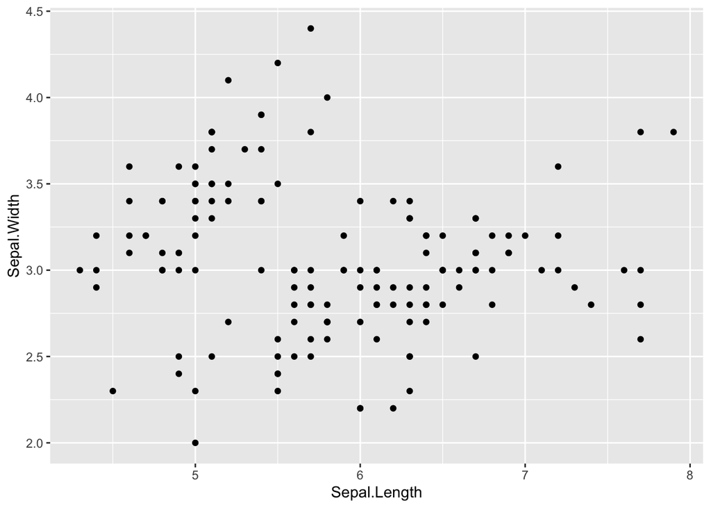

```r
ggplot(iris, aes(x=Sepal.Length, y=Sepal.Width)) +
  geom_point()
```

**Q1**: Make a scatterplot between the Petal Length and Petal Width. How many clusters do you see?

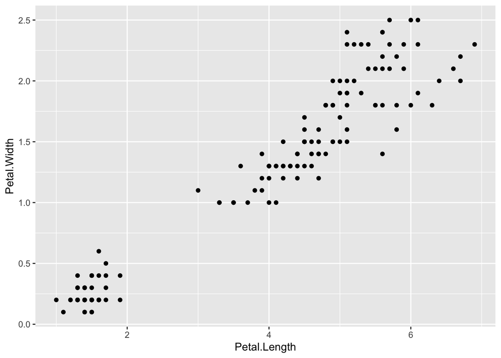

```r
#Question 1
#Code
ggplot(iris, aes(x=Petal.Length, y=Petal.Width)) +
  geom_point()
```

```r
#Answer
#There are two clusters visible, probably due to species
```

## 2.2 Histrograms

One of the first things to check when you are visualy exploring a dataset is the distribution of its variables. A common way to do this is by plotting a histogram. With **ggplot** you can do this easily by using `geom_histogram()`. For instance we can look at the distribution of petal lengths with the following command:

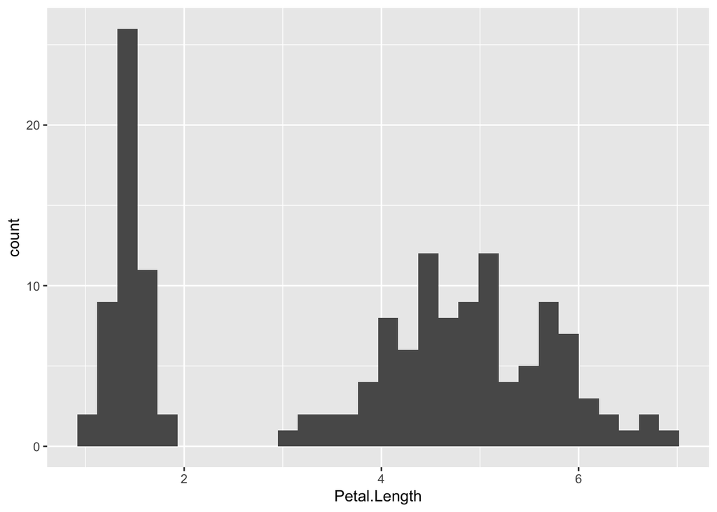

```r
ggplot(iris, aes(x=Petal.Length)) +
  geom_histogram()
```

As you can see, `aes()` function now only takes one argument (x) since we are only interested in the distribution of one variable.

The length of every bin is the number of observations within the range (width) of each bin. You can customize the width of each bin with the `binwidth` argument. This might be useful if the dataset contains many more observations:

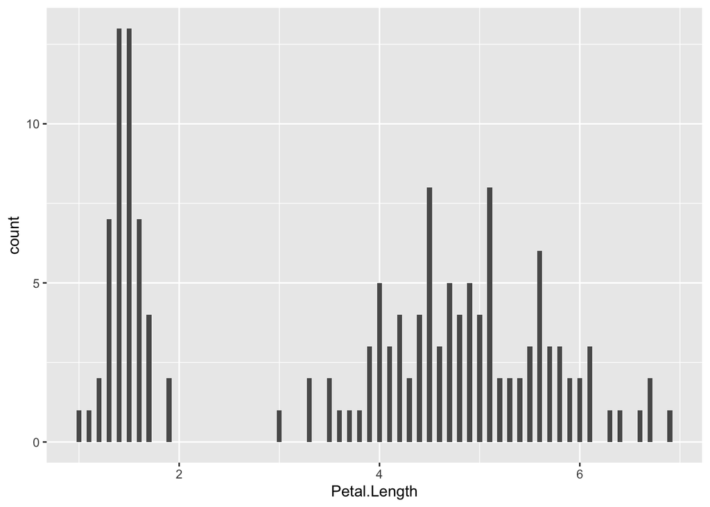

```r
ggplot(iris, aes(x=Petal.Length)) +
  geom_histogram(binwidth = 0.05)
```

**Q2**

- Make a histogram of the Sepal length
- Use `binwidth = 0.05`
- By looking at the plot: what sepal length is most prevalent?

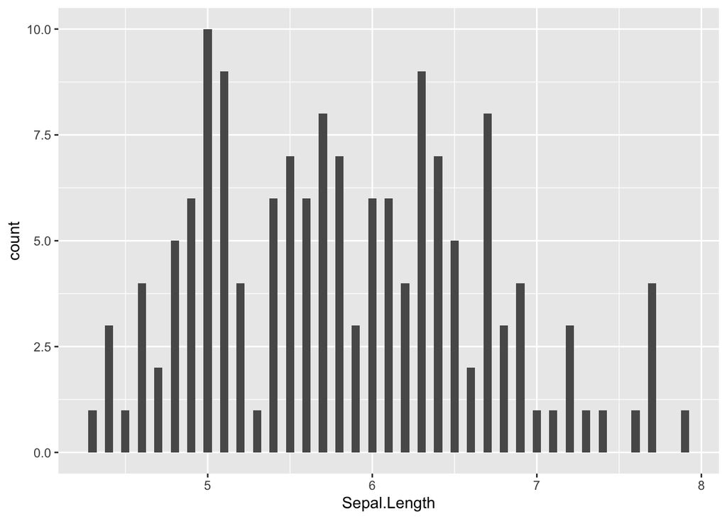

```r
#Question 2
#Code
ggplot(iris, aes(x=Sepal.Length)) +
  geom_histogram(binwidth = 0.05)
```

```r
#Answer
#The most counted length (10 times) is exactly 5 cm
```

## 2.3 Boxplots

Since the iris dataset includes different species we can use boxplots to compare the distribution of values between these groups.

**Q3**:

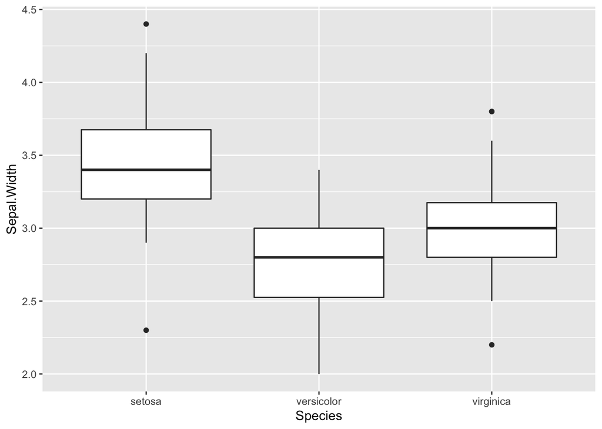

```r
#Question 3
#Code
ggplot(iris, aes(x=Species, y=Sepal.Width)) +
  geom_boxplot()
```

```r
#Answer
#The largest mean sepal width is measured in the setosa iris flowers
```

## 2.4 Saving plots

In **ggplot2** it is possible to add extra options to a plot by simply on top of the `ggplot()` function. Therefore it can be convenient to store the result of `ggplot()` inside a variable. For example:

```r
plot1 <- ggplot(iris, aes(x=Species, y=Sepal.Width))
plot2 <- plot1 + geom_boxplot()
plot3 <- plot2 + theme_bw()
```

Notice that this won’t generate any graphical output. Like with any assignment, this will not immediately print the content of the variable `plot3`.

**Q4** Consecutively type `plot1`, `plot2`, `plot3`. What is added in each plot?

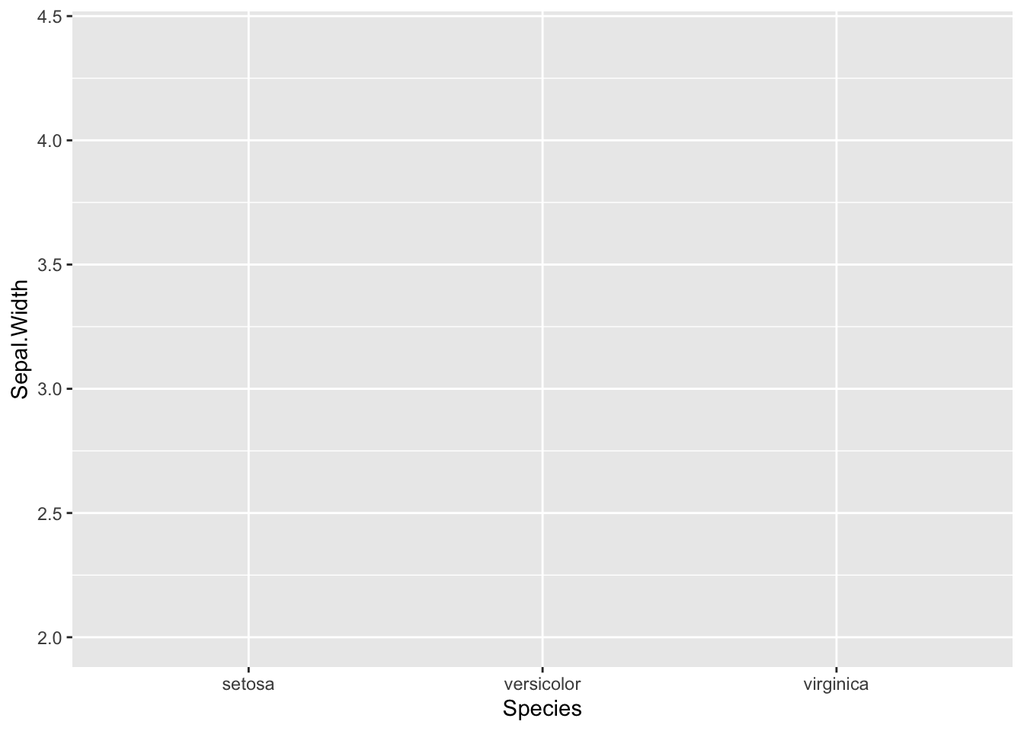

```r
#Question 4
#Code
plot1
```

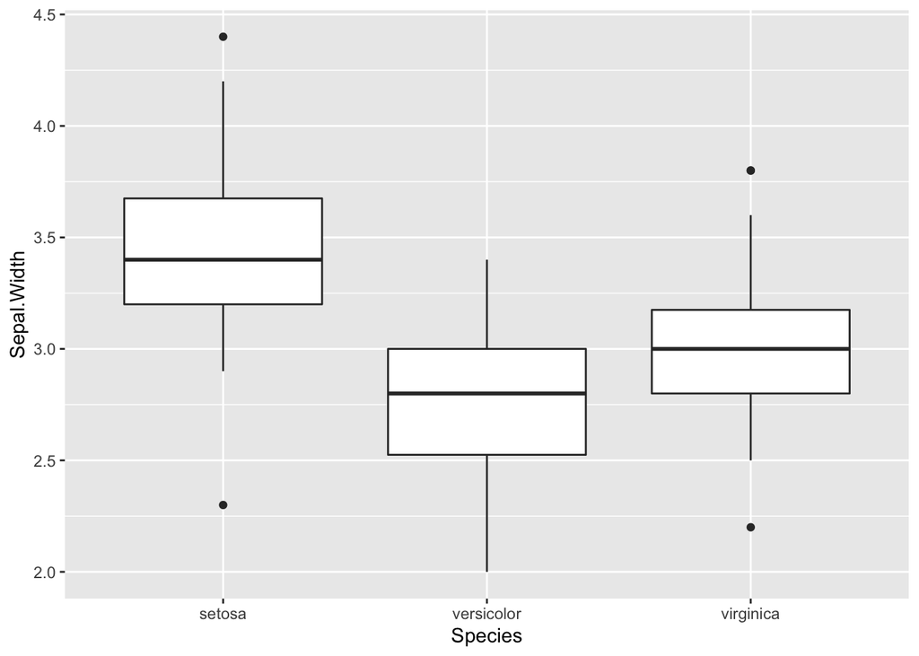

```r
plot2
```

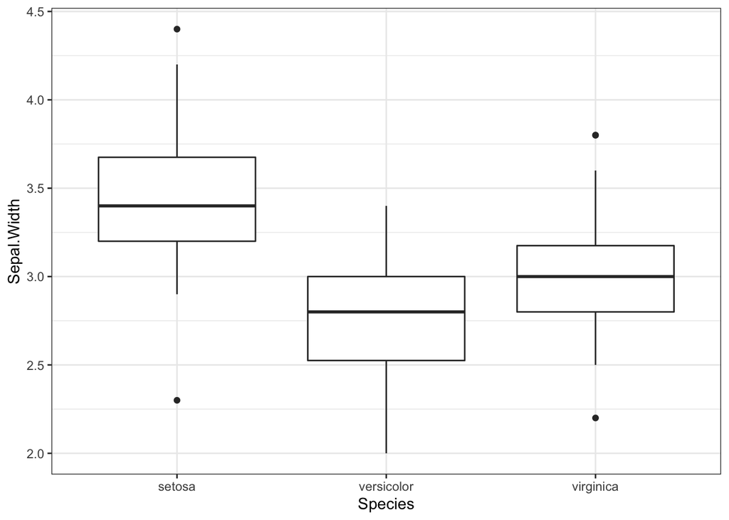

```r
plot3
```

```r
#Answer
#First plot: empty outline
#Second plot: boxplot of Sepal Width
#Thirs plot: different background
```

**Q5**

- Make a boxplot of sepal length
- Save it under the name `sepal.length.boxplot`

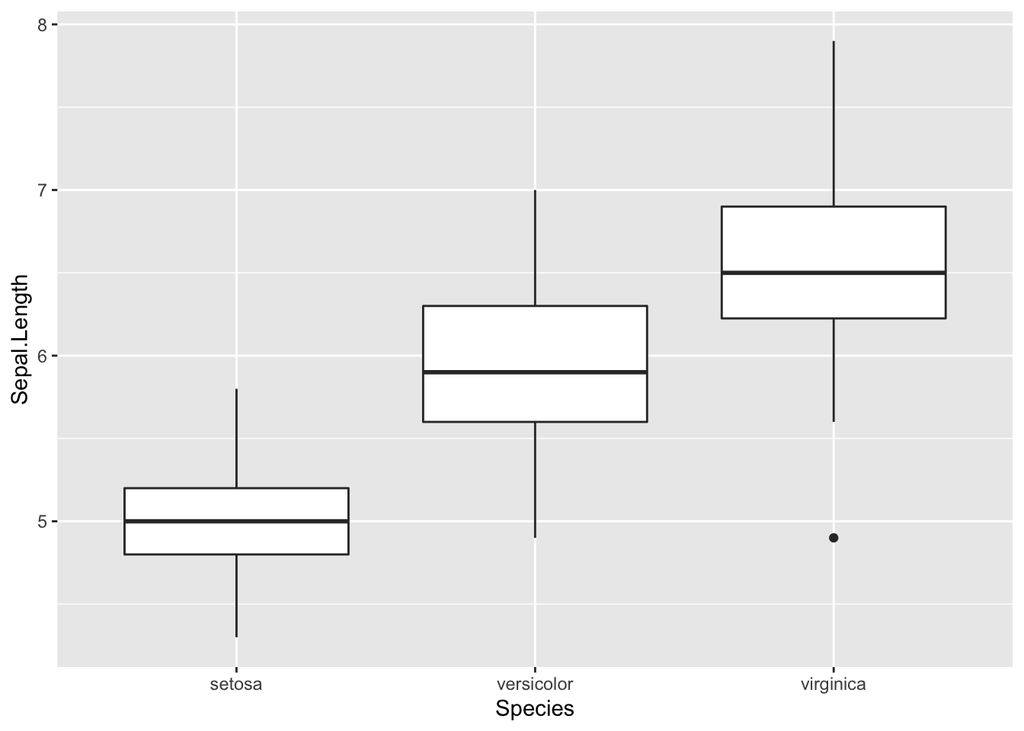

```r
#Question 5
#Code
plot1 <- ggplot(iris, aes(x=Species, y=Sepal.Length))
sepal.length.boxplot <- plot1 + geom_boxplot()
sepal.length.boxplot
```

# 3 Improving plots

## 3.1 Adding shapes

Now we have stored the plot, we can add shapes to the plot by adding to the `sepal.length.boxplot` variable. The functions `geom_hline()` and `geom_vline()` are used to add horizontal and vertical lines to a plot. For instance we can draw a horizontal line over the plot to indicate what the mean is of sepal lengths for the complete dataset. The only argument these functions need is the interception of the x- or y-axis.

**Q6**

- Calculate the mean Sepal length across all species
- Save this mean as `sepal.length.mean`
- Add the mean as a line to sepal.length.boxplot using `geom_hline(yintercept = sepal.length.mean)`
- Make the line stand out by adding `color = "red"` within the brackets of `geom_hline()`
- Do you think the mean is representative of all species? Does it overlap with the ‘whiskers’ of the boxplot?

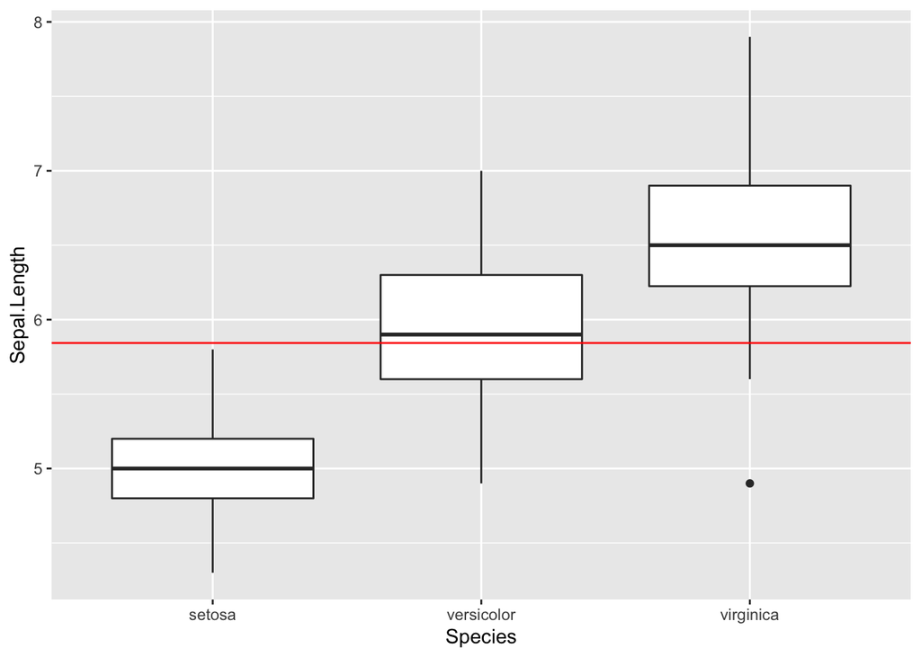

```r
#Question 6
#Code

# First calculate the mean
sepal.length.mean <- mean(iris$Sepal.Length)

# Add a horizontal line to the plot
sepal.length.boxplot +
  geom_hline(yintercept = sepal.length.mean, color = "red")
```

```r
#Answer
#No, the mean across all species does not overlap with the whiskers of setosa
#The mean is almost equal to the mean for versicolor but clearly not for
#setosa and virginica
```

## 3.2 Adding text

Previously we have determined if there was a significant differences in petal lengths using a t-test. The p-value yielded by this test is very informative and can be added to plot easily.

**Q7**

- Run a t-test to determine the difference in means of sepal length between *Iris virginica* and *Iris versicolor*
- Store the p-value in a variable called `t.test.p.value`
- What is the p-value?

```r
#Question 7
#Code
t.test.p.value <- t.test(iris[iris$Species == 'virginica',]$Sepal.Length, iris[iris$Species == 'versicolor',]$Sepal.Length)$p.value
t.test.p.value
```

```
## [1] 1.866144e-07
```

```r
#Answer
#the p-value is 1.866144e-07
```

To annotate the boxplot with the p-value of the t-test, we can use the `annotate()` function. We need to provide what type of annotation we want, the x and y position and the actual text of the annotation. But first we have to format the label properly.

**Q8**

- Round the 3 p-value to 3 significant digits using `signif()` and save the new value as `t.test.p.value` again
- Create a label using `paste("p-value =", t.test.p.value)`
- Save the label as `p.value.label`
- Add the annotation to the boxplot: `+ annotate("text", x = 1.5, y = 8, label = p.value.label)`
- Adjust the position of the `p.value.label` to the right lower *Hint*: play around with the values of x and y in `annotate()` until the label is placed where you like it

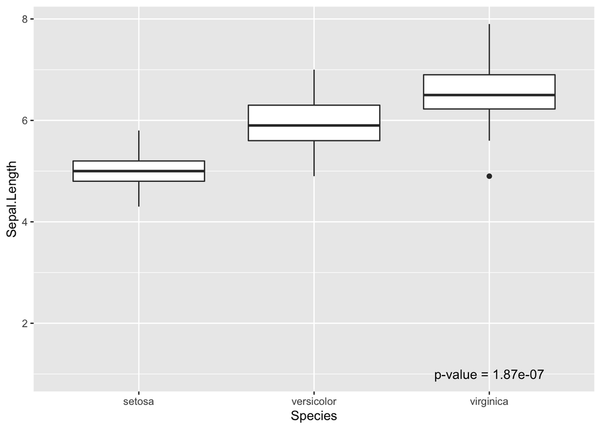

```r
#Question 8
#Code
# Round the p-value to 3 digits
t.test.p.value <- signif(t.test.p.value, 3)
# Create a string by pasting "p-value =" and the p-value
p.value.label <- paste("p-value =", t.test.p.value)
# Plot the boxplot + the annotation
sepal.length.boxplot + annotate("text", x = 3, y = 1, label = p.value.label)
```

## 3.3 Adding layers

While **ggplot2** makes good plots right out off the box, they are also highly adjustable.

Basically every line, colour, shape or text in the plot can be adjusted. Let’s enhance our boxplot a bit by adding the actual data points as dots by adding `geom_point()`.

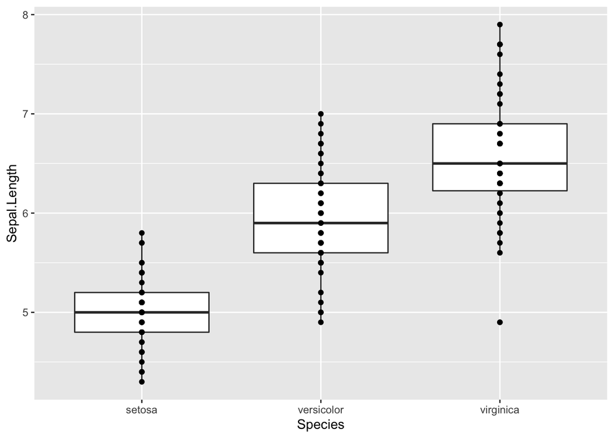

```r
sepal.length.boxplot +
  geom_point()
```

Because we are plotting in one dimension, the above statement will draw all dots on a single line. Since some measurements might overlap it is a good idea to add some random noise to the ‘x’ position of each point. We can adjust the x position by using the `position` argument of the `geom_point()` function. The random noise can be added using `"jitter"` as value. To move the points a bit to the background we can also adjust the size, color and transparency using the `size`, `color`, `alpha` arguments.

**Q9**

- Make a new boxplot of Sepal length called `sepal.length.boxplot.jitter`
- In the brackets of `geom_point()`, add the following: `position = "jitter"` `size = 1` `alpha = 0.5` `color = c("COLORNAME")`
- Fill in a color you like, mabye `"blue"` or `"cyan"`
- Check out all kinds of color names in R in this [overview] (http://www.stat.columbia.edu/~tzheng/files/Rcolor.pdf)
- If you make the same plot a few times in a row, are they exactly the same? Why (not)?

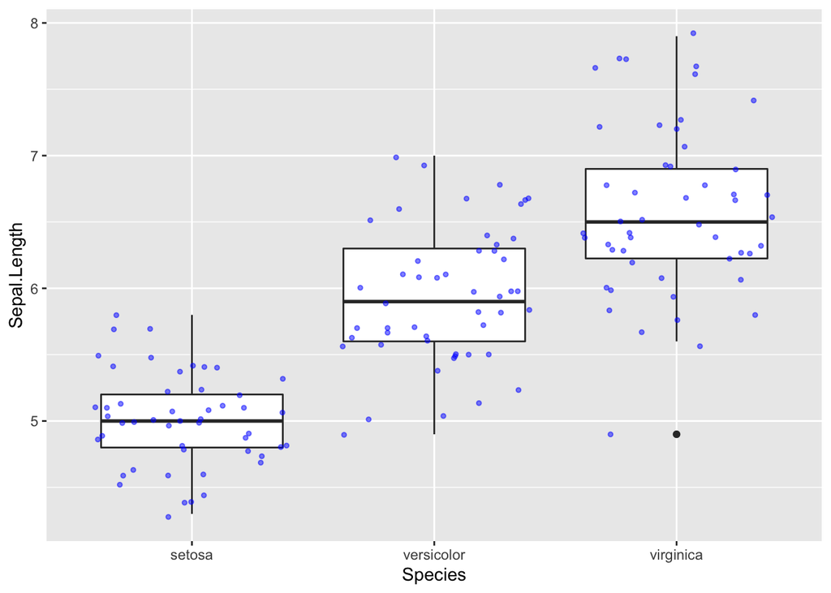

```r
#Question 9
#Code
sepal.length.boxplot.jitter <- sepal.length.boxplot +
                        geom_point(position = "jitter", size=1, color=c("blue"), alpha=0.5)
sepal.length.boxplot.jitter
```

```r
#Answer
#The plots will change ever so slightly because there is a random component to the jitter function that moves the dots around a little differently every time.
```

## 3.4 Changing axis labels

Sometimes it is useful to change the sizes of the labels. For instance when you want to use your plots for a presentation or for a poster you want to increase the font size of the labels, so that the people in the back of the room also have an idea what you are talking about. We can do this by using the `theme()` function. Type `?theme` in your console to see what arguments can be used when calling this function.

As you can see there are a lot of arguments available, we can use the `axis.title` argument to adjust both axes at once. To change them separately we could use `axis.title.x` and `axis.title.y`:

```r
sepal.length.boxplot +
  theme(axis.title = element_text(size = 15))
```

[output not shown]

The text of the label on the y axis “Sepal.Length” is not despriptive enough. All the measurements of the iris dataset are in centimeters, so we should add the unit here. To change the text of the y label we can use the `ylab()` function and add it to plot like we are used to.

**Q10**

- Start with your saves `sepal.length.boxplot.jitter`
- Change the axis labels to be larger (see example code above)
- Change the y-axis label text to include the units: `"Sepal length (cm)"`
- Store the new plot as `sepal.length.boxplot.labels`

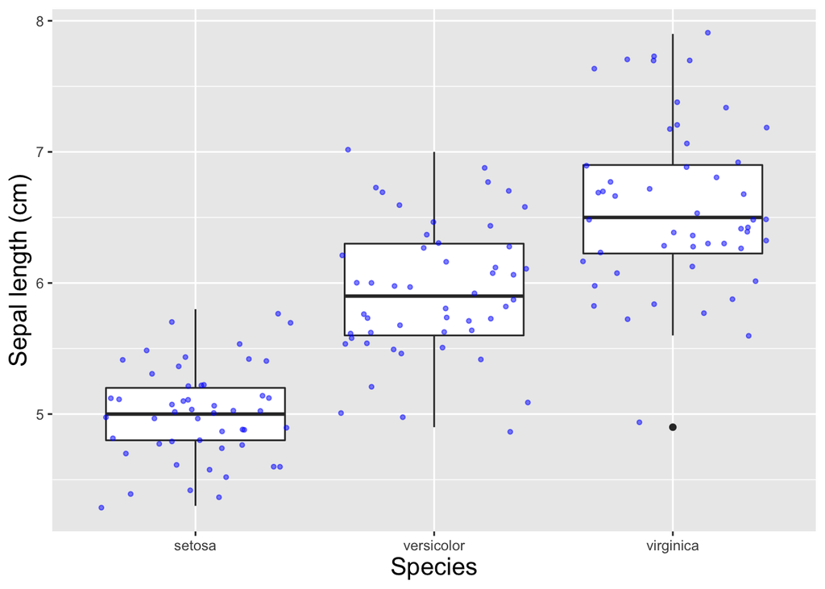

```r
#Question 10
#Code
sepal.length.boxplot.labels <- sepal.length.boxplot.jitter +
                        theme(axis.title = element_text(size = 15)) +
                        ylab("Sepal length (cm)")
sepal.length.boxplot.labels
```

The size of the text of the species beneath the boxplots can also be increased by adding more arguments to the `theme()` function. The argument we need to change the text of axis is `axis.text.x`.

**Q11**

- Start with your saves `sepal.length.boxplot.labels`
- Change the x-axis species text size using `theme(axis.text.x = element_text(size = 3))`
- What’s wrong?
- Adjust the mistake and save the result as `sepal.length.boxplot.sizes`

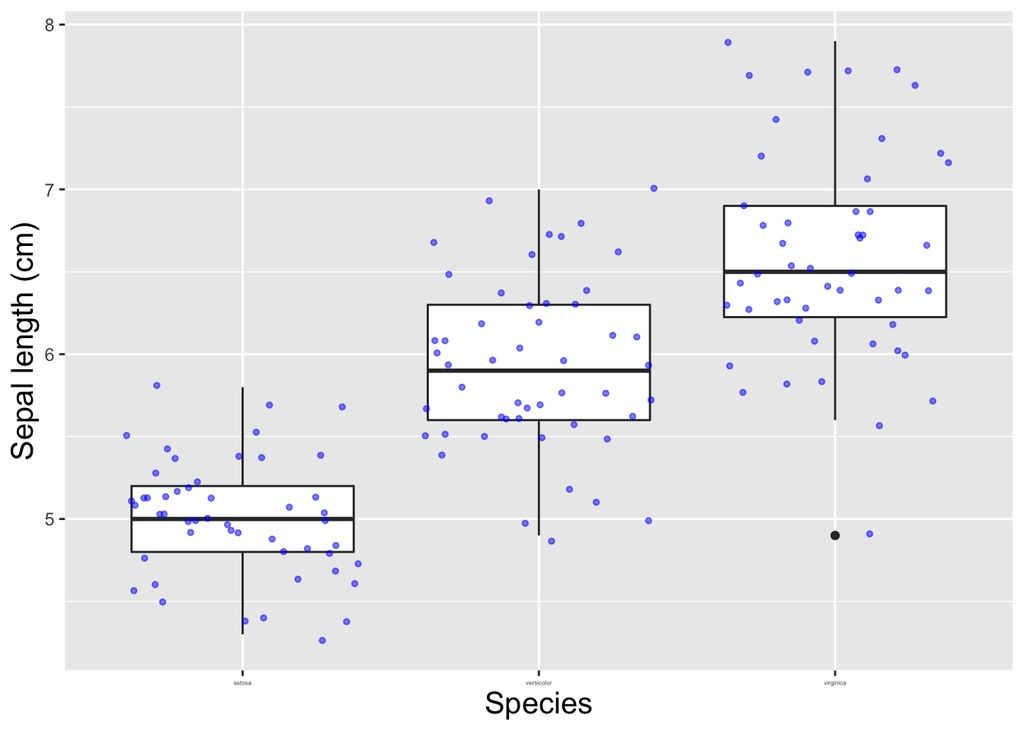

```r
#Question 11
#Code
sepal.length.boxplot.labels + theme(axis.text.x = element_text(size = 3))
```

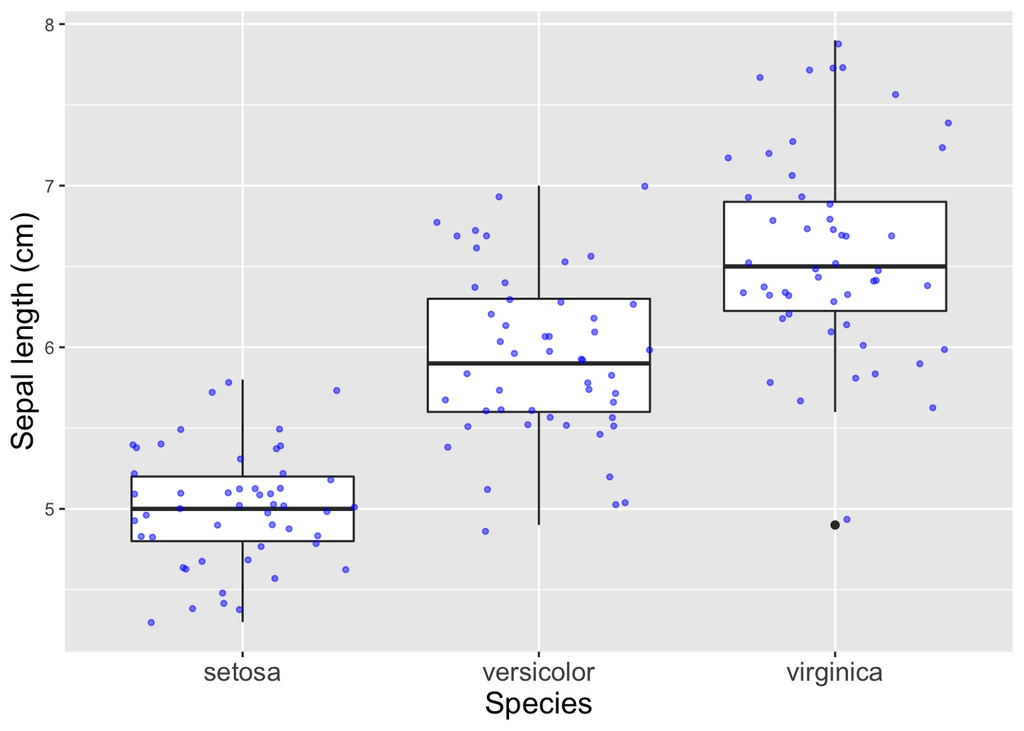

```r
sepal.length.boxplot.sizes <- sepal.length.boxplot.labels +
                        theme(axis.text.x = element_text(size = 13))
sepal.length.boxplot.sizes
```

```r
#Answer
#The labels become way too small with size = 3
```

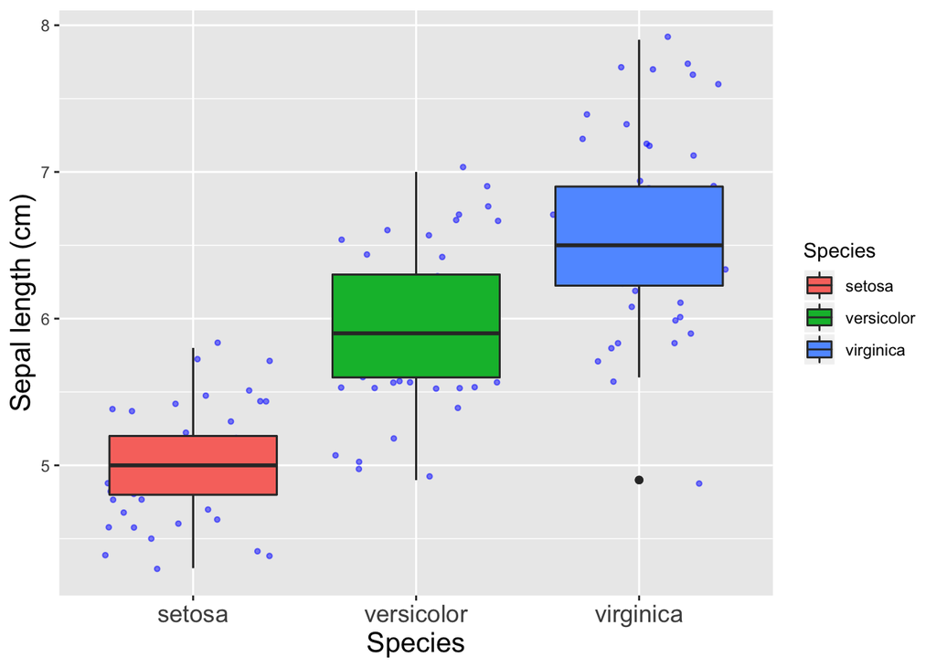

```r
sepal.length.boxplot.sizes +
  geom_boxplot(aes(fill=Species))
```

As you can see the boxplot is drawn on top of `geom_point`, this is because we have added the boxplot as another layer on top of the previous plot.

**Q12**:

- Recreate the coloured boxplot above so that the points lay on top of the boxplot
- Call the new boxplot `sepal.length.boxplot.new`
- Change the colour of the dots if you do not like the combination with the box plot colours

```r
#Question 12
#Code
sepal.length.boxplot.new <- ggplot(iris, aes(x=Species, y=Sepal.Length,fill=Species)) +
                        geom_boxplot() +
                        geom_point(position = "jitter", size=1, color=c("navy"), alpha=0.5)+
                        theme(axis.title = element_text(size = 15),
                              axis.text.x = element_text(size = 13)) +
                        ylab("Sepal length (cm)")
#sepal.length.boxplot.new
```

Not everyone likes the grey background. An easy way to remove these (and to make the plot look less like a default ggplot) is to add `theme_bw()`:

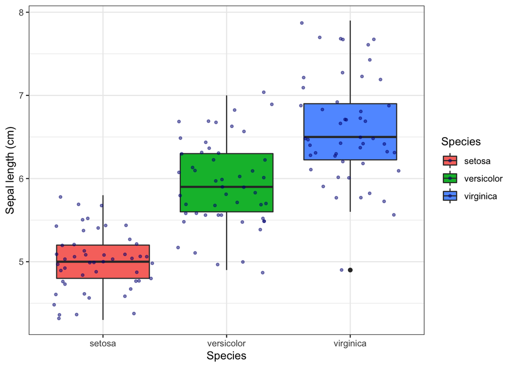

```r
sepal.length.boxplot.new +
  theme_bw()
```

# 4 Grouped plots

## 4.1 Melting data

There are many situations where data is presented in a format that is not ready to dive straight to exploratory data analysis or to use a desired statistical method. The **reshape2** package for R provides useful functionality to avoid having to hack data around in a spreadsheet prior to import into R. More recently, it has become the norm to use the **dplyr** package for reformatting data, and although I highly recommend that you use **dplyr** if you are going to work more in R, it does require a little getting used to. Therefore, we will stick to **reshape2** for this tutorial.

The `melt()` function takes data formatted as a matrix with a set of columns, like our data, and formats it into a single column. For some application of GGplot we need this format. To make use of the function we need to specify a data frame, the id variables (which will be left at their settings) and the measured variables (columns of data) to be stacked. The default assumption on measured variables is that it is all columns which are not specified as id variables.

Load the **reshape2** library, so we can use the `melt()` function, and print the `head()` of **iris** again.

```
##   Sepal.Length Sepal.Width Petal.Length Petal.Width Species
## 1          5.1         3.5          1.4         0.2  setosa
## 2          4.9         3.0          1.4         0.2  setosa
## 3          4.7         3.2          1.3         0.2  setosa
## 4          4.6         3.1          1.5         0.2  setosa
## 5          5.0         3.6          1.4         0.2  setosa
## 6          5.4         3.9          1.7         0.4  setosa
```

Our id variable is `Species`, so we use this the value of the `id.vars` argument of the melt function. All the other columns are variables we would like to use and therefore we do not have to specify the `measure.vars` argument.

```r
iris.melt <- melt(iris, id.vars = "Species")
```

**Q13**

- Explore the new reformatted data frame `iris.melt` using `head()`, `dim()` and `str()`
- What does each of the columns indicate?
- How is this different from the initial dataset?

```r
#Question 13
#Code
head(iris.melt)
```

```
##   Species     variable value
## 1  setosa Sepal.Length   5.1
## 2  setosa Sepal.Length   4.9
## 3  setosa Sepal.Length   4.7
## 4  setosa Sepal.Length   4.6
## 5  setosa Sepal.Length   5.0
## 6  setosa Sepal.Length   5.4
```

```r
str(iris.melt)
```

```
## 'data.frame':    600 obs. of  3 variables:
##  $ Species : Factor w/ 3 levels "setosa","versicolor",..: 1 1 1 1 1 1 1 1 1 1 ...
##  $ variable: Factor w/ 4 levels "Sepal.Length",..: 1 1 1 1 1 1 1 1 1 1 ...
##  $ value   : num  5.1 4.9 4.7 4.6 5 5.4 4.6 5 4.4 4.9 ...
```

```r
dim(iris.melt)
```

```
## [1] 600   3
```

```r
#Answer
#The first column shows species
#The second column shows the four variables (sepal length, sepal width, petal length, petal width)
#The third column includes the actual measurement in cm
```